# Lana Del Rey Energy

Allison Kim

## INTRODUCTION

The main goal of this project is to build a model to predict the energy level of one of Lana Del Rey’s songs.

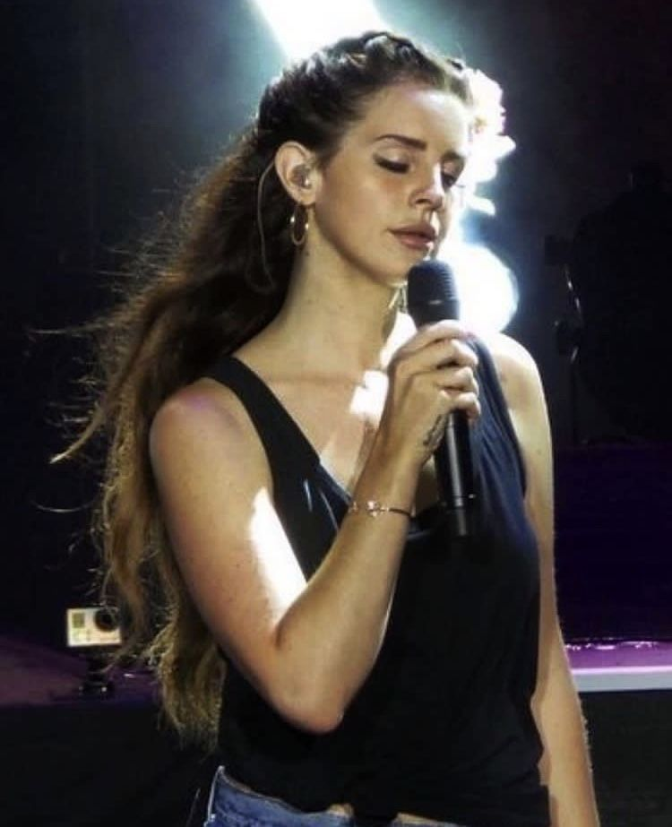

Lana Del Rey

### Who is Lana Del Rey?

Elizabeth Woolridge Grant (born June 21, 1985), known professionally as Lana Del Rey, is an American singer-songwriter. She is the recipient of various accolades, including two Brit Awards, two Billboard Women in Music, two MTV Europe Music Awards, and a Satellite Award, in addition to nominations for six Grammy Awards and a Golden Globe Award. Rolling Stone placed Del Rey in their list of 200 Greatest Singers of All Time (2023), and also Rolling Stone UK named her The Greatest American Songwriter of the 21st century (2023).Time magazine named Del Rey one of the 100 most influential people in the world in 2012.

### What are we trying to do?

The question I would like to answer is: How can we predict the energy level of one of Lana Del Rey’s songs? Based on given information about musical elements such as the acousticness, the valence, tempo, etc. I think it would be possible to predict the energy level of a song. Lana Del Rey’s music has a wide range of sounds, and I think it would be interesting to examine how certain musical qualities can give us insight into how energetic one of her songs is.

## LOADING PACKAGES AND DATA

Let’s start off by loading all necessary packages and data. This data is taken from [Kaggle](https://www.kaggle.com/datasets/arthurboari/lana-del-rey-spotify-data) and it contains information on all of Lana Del Rey’s songs from 2011-2021.

```r
# Load packages

library(tidyverse)
library(dplyr)
library(tidymodels)
library(readr)
library(kknn)
library(janitor)
library(ISLR)
library(discrim)
library(poissonreg)
library(glmnet)
library(corrr)
library(corrplot)
library(randomForest)
library(xgboost)
library(rpart.plot)
library(vip)
library(ranger)
library(tidytext)
library(ggplot2)
library(knitr)
library(kableExtra)
theme_set(theme_bw())

# Read in data

Lana <- read_csv("Akim-FinalProject/data/unprocessed/Lana Del Rey Spotify Data.csv")
tidymodels_prefer()
head(Lana) %>%
  kable() %>%
  kable_styling(full_width = F) %>%
  scroll_box(width = "100%", height = "200px")
```

| artist_name | artist_id | album_id | album_type | album_release_date | album_release_year | album_release_date_precision | danceability | energy | key | loudness | mode | speechiness | acousticness | instrumentalness | liveness | valence | tempo | track_id | analysis_url | time_signature | disc_number | duration_ms | explicit | track_href | is_local | track_name | track_preview_url | track_number | type | … |
| --- | --- | --- | --- | --- | --- | --- | --- | --- | --- | --- | --- | --- | --- | --- | --- | --- | --- | --- | --- | --- | --- | --- | --- | --- | --- | --- | --- | --- | --- | --- |
| Lana Del Rey | 00FQb4jTyendYWaN8pK0wa | 7dOavETswy5TKZBQGDqqu4 | album | 2011-01-01 | 2011 | day | 0.316 | 0.636 | 4 | -6.631 | 0 | 0.0424 | 0.1860 | 0.000160 | 0.1980 | 0.400 | 171.564 | 73lffcpq5QqMR1dOokAV7y | https://api.spotify.com/v1/audio-analysis/73lffcpq5QqMR1dOokAV7y | 4 | 1 | 286253 | FALSE | https://api.spotify.com/v1/tracks/73lffcpq5QqMR1dOokAV7y | FALSE | Born To Die | NA | 1 | track | … |
| Lana Del Rey | 00FQb4jTyendYWaN8pK0wa | 7dOavETswy5TKZBQGDqqu4 | album | 2011-01-01 | 2011 | day | 0.392 | 0.724 | 4 | -5.566 | 0 | 0.0594 | 0.0633 | 0.001920 | 0.4070 | 0.129 | 160.090 | 2zltAwjiW6O9fpsMl13F6i | https://api.spotify.com/v1/audio-analysis/2zltAwjiW6O9fpsMl13F6i | 4 | 1 | 299920 | FALSE | https://api.spotify.com/v1/tracks/2zltAwjiW6O9fpsMl13F6i | FALSE | Off To The Races | NA | 2 | track | … |
| Lana Del Rey | 00FQb4jTyendYWaN8pK0wa | 7dOavETswy5TKZBQGDqqu4 | album | 2011-01-01 | 2011 | day | 0.565 | 0.834 | 3 | -4.472 | 1 | 0.0622 | 0.4110 | 0.000000 | 0.0811 | 0.490 | 117.935 | 6YFGHUzgTuYwiUbRn7czUf | https://api.spotify.com/v1/audio-analysis/6YFGHUzgTuYwiUbRn7czUf | 4 | 1 | 209453 | FALSE | https://api.spotify.com/v1/tracks/6YFGHUzgTuYwiUbRn7czUf | FALSE | Blue Jeans | NA | 3 | track | … |
| Lana Del Rey | 00FQb4jTyendYWaN8pK0wa | 7dOavETswy5TKZBQGDqqu4 | album | 2011-01-01 | 2011 | day | 0.251 | 0.256 | 6 | -9.682 | 0 | 0.0311 | 0.8120 | 0.000000 | 0.0884 | 0.168 | 82.290 | 7mc6gNNKbrCrYGDoVKaVna | https://api.spotify.com/v1/audio-analysis/7mc6gNNKbrCrYGDoVKaVna | 5 | 1 | 281946 | FALSE | https://api.spotify.com/v1/tracks/7mc6gNNKbrCrYGDoVKaVna | FALSE | Video Games | NA | 4 | track | … |
| Lana Del Rey | 00FQb4jTyendYWaN8pK0wa | 7dOavETswy5TKZBQGDqqu4 | album | 2011-01-01 | 2011 | day | 0.459 | 0.684 | 10 | -5.971 | 0 | 0.0881 | 0.2850 | 0.000000 | 0.4250 | 0.605 | 175.728 | 48SdtsEKujibZPrd6UMfAr | https://api.spotify.com/v1/audio-analysis/48SdtsEKujibZPrd6UMfAr | 4 | 1 | 222920 | FALSE | https://api.spotify.com/v1/tracks/48SdtsEKujibZPrd6UMfAr | FALSE | Diet Mountain Dew | NA | 5 | track | … |
| Lana Del Rey | 00FQb4jTyendYWaN8pK0wa | 7dOavETswy5TKZBQGDqqu4 | album | 2011-01-01 | 2011 | day | 0.538 | 0.901 | 0 | -5.999 | 0 | 0.2150 | 0.5420 | 0.000152 | 0.1010 | 0.423 | 84.951 | 70hhwXAexehepJIaS6Kxb9 | https://api.spotify.com/v1/audio-analysis/70hhwXAexehepJIaS6Kxb9 | 4 | 1 | 230533 | FALSE | https://api.spotify.com/v1/tracks/70hhwXAexehepJIaS6Kxb9 | FALSE | National Anthem | NA | 6 | track | … |

## TIDYING THE DATA

Let’s check the shape of the data.

```r
# Check shape of Lana

dim(Lana)
```

```
## [1] 593  36
```

The data contains 593 rows and 36 columns which means there are 593 total songs and 36 variables. 593 songs seems abnormally high. Let’s check how many *distinct* albums and tracks are included in this data.

```r
# Check number of unique albums

count(distinct(Lana, album_name))
```

```
## # A tibble: 1 × 1
##       n
##   <int>
## 1    14
```

```r
# Check number of unique tracks

count(distinct(Lana, track_name))
```

```
## # A tibble: 1 × 1
##       n
##   <int>
## 1   121
```

There are 14 albums and 121 unique song names, wow that’s a lot of repeats in the data!! There are a few albums with repeat song names, for example I expect Born to Die and Born to Die-Paradise Edition to have a few of the same song names. This data, however, likely includes some repeat song names in the *same* album, which we don’t want. In order to fix this issue, let’s selects all of the *unique* track names in each of the 14 albums.

```r
# Keeping only the unique tracks in each unique album

Lana1<-Lana%>%
  distinct(album_name, track_name, .keep_all = TRUE)

# Check shape

dim(Lana1)
```

```
## [1] 233  36
```

We’ve now narrowed it down to 233 tracks, meaning no repeat songs in each album. This means that there were 593-233=360 repeat songs that we got rid of and 233-121=112 repeat songs that were in *different* albums, we could keep these for the purpose of analyzing all songs in all of Lana Del Rey’s albums, however, this could skew our data. Repeated songs would contain the same values for each of the variables, so we will get rid of these as well leaving us with 121 unique songs.

```r
# Keep only unique tracks

Lana2 <- Lana %>%
  filter(!duplicated(track_name))

# Kheck shape

dim(Lana2)
```

```
## [1] 121  36
```

Now let’s check all the names of the albums.

```r
# Print unique album names

albums <- unique(Lana2$album_name)
albums
```

```
##  [1] "Born To Die"
##  [2] "Born To Die (Deluxe Version)"
##  [3] "Born To Die - The Paradise Edition"
##  [4] "Born To Die – Paradise Edition (Special Version)"
##  [5] "Born To Die – The Paradise Edition (Bonus Version)"
##  [6] "Ultraviolence"
##  [7] "Ultraviolence (Deluxe)"
##  [8] "Honeymoon"
##  [9] "Lust For Life"
## [10] "Norman Fucking Rockwell!"
## [11] "Chemtrails Over The Country Club"
## [12] "Blue Banisters"
```

We can see that there are 5 versions of Born to Die and 2 of Ultraviolence. Let’s combine these, since we already got rid of the repeated songs.

```r
# Merge different versions of same album

Lana3 <- Lana2 %>%
  mutate(album_name = ifelse(str_detect(album_name, "Born To Die"),
                             "Born to Die (all versions)",
                             album_name)) %>%
  mutate(album_name = ifelse(str_detect(album_name, "Ultraviolence"),
                             "Ultraviolence (all versions)",
                             album_name))

# Count how many updated albums

count(distinct(Lana3, album_name))
```

```
## # A tibble: 1 × 1
##       n
##   <int>
## 1     7
```

Great! We’ve successfully combined all Born to Die versons and all Ultraviolence versions. Now we have 7 albums to work with.

### Variable Selection

There are still 36 variables in the data. Let’s narrow that down to just the ones that will help us predict the `energy` variable. But first let’s define `energy` in this context:

- `energy`: Energy is a measure from 0.0 to 1.0 and represents a perceptual measure of intensity and activity. Typically, energetic tracks feel fast, loud, and noisy.

The variables I have chosen to predict this are:

- `danceability`: Describes how suitable a track is for dancing based on a combination of musical elements including tempo, rhythm stability, beat strength, and overall regularity. A value of 0.0 is least danceable and 1.0 is most danceable.
- `loudness`: The overall loudness of a track in decibels (dB). Loudness values are averaged across the entire track and are useful for comparing relative loudness of tracks. Values typical range between -60 and 0 db.
- `acousticness`: A confidence measure from 0.0 to 1.0 of whether the track is acoustic. 1.0 represents high confidence the track is acoustic.
- `instrumentalness`: Predicts whether a track contains no vocals. “Ooh” and “aah” sounds are treated as instrumental in this context. Rap or spoken word tracks are clearly “vocal”. The closer the instrumentalness value is to 1.0, the greater likelihood the track contains no vocal content. Values above 0.5 are intended to represent instrumental tracks, but confidence is higher as the value approaches 1.0.
- `tempo`: The overall estimated tempo of a track in beats per minute (BPM). In musical terminology, tempo is the speed or pace of a given piece and derives directly from the average beat duration.
- `speechiness`: Detects the presence of spoken words in a track. The more exclusively speech-like the recording, the closer to 1.0 the attribute value. Values above 0.66 describe tracks that are probably made entirely of spoken words. Values below 0.33 most likely represent music and other non-speech-like tracks.
- `liveness`: Detects the presence of an audience in the recording. Higher liveness values represent an increased probability that the track was performed live. A value above 0.8 provides strong likelihood that the track is live.
- `valence`: A measure from 0.0 to 1.0 describing the musical positiveness conveyed by a track. Tracks with high valence sound more positive (e.g. happy, cheerful, euphoric), while tracks with low valence sound more negative (e.g. sad, depressed, angry).

All of these variables take on continuous values, so this problem will be a regression problem.

```r
# Select only variables of interest

Lana4 <- Lana3 %>%
  select(c("track_name", "album_name", "danceability", "energy", "loudness",  "acousticness", "instrumentalness", "tempo", "speechiness", "liveness", "valence"))
```

For the sake of clarity and exploratory data analysis, I’ve decided to keep the variables `track_name` and `album_name`

- `track_name`: The name of the track
- `album_name`: The name of the album that the track is from

### Missigness

To deal with potential missing data let’s check if our tidied data has any missing values.

```r
# Check how many missing values

sum(is.na(Lana4))
```

```
## [1] 0
```

There is no missing data! We can now move on to finalizing the data.

```r
# Create final dataset

write_csv(Lana4, 'Lana_final.csv')

# Assign final data to a variable and read in

Lana_data<-read_csv('Lana_final.csv', show_col_types = FALSE)
Lana_data %>%
  kable() %>%
  kable_styling(full_width = F) %>%
  scroll_box(width = "100%", height = "200px")
```

| track_name | album_name | danceability | energy | loudness | acousticness | instrumentalness | tempo | speechiness | liveness | valence |
| --- | --- | --- | --- | --- | --- | --- | --- | --- | --- | --- |
| Born To Die | Born to Die (all versions) | 0.316 | 0.6360 | -6.631 | 1.86e-01 | 1.60e-04 | 171.564 | 0.0424 | 0.1980 | 0.4000 |
| Off To The Races | Born to Die (all versions) | 0.392 | 0.7240 | -5.566 | 6.33e-02 | 1.92e-03 | 160.090 | 0.0594 | 0.4070 | 0.1290 |
| Blue Jeans | Born to Die (all versions) | 0.565 | 0.8340 | -4.472 | 4.11e-01 | 0.00e+00 | 117.935 | 0.0622 | 0.0811 | 0.4900 |
| Video Games | Born to Die (all versions) | 0.251 | 0.2560 | -9.682 | 8.12e-01 | 0.00e+00 | 82.290 | 0.0311 | 0.0884 | 0.1680 |
| Diet Mountain Dew | Born to Die (all versions) | 0.459 | 0.6840 | -5.971 | 2.85e-01 | 0.00e+00 | 175.728 | 0.0881 | 0.4250 | 0.6050 |
| National Anthem | Born to Die (all versions) | 0.538 | 0.9010 | -5.999 | 5.42e-01 | 1.52e-04 | 84.951 | 0.2150 | 0.1010 | 0.4230 |
| Dark Paradise | Born to Die (all versions) | 0.579 | 0.6360 | -8.354 | 1.17e-01 | 0.00e+00 | 120.041 | 0.0649 | 0.1720 | 0.4030 |
| Radio | Born to Die (all versions) | 0.326 | 0.8430 | -5.242 | 2.19e-01 | 2.63e-05 | 75.139 | 0.0893 | 0.0877 | 0.1670 |
| Carmen | Born to Die (all versions) | 0.506 | 0.4240 | -9.568 | 8.64e-02 | 3.76e-04 | 100.017 | 0.0317 | 0.1270 | 0.0380 |
| Million Dollar Man | Born to Die (all versions) | 0.201 | 0.5860 | -5.979 | 4.94e-01 | 0.00e+00 | 195.767 | 0.0566 | 0.0662 | 0.5320 |
| Summertime Sadness | Born to Die (all versions) | 0.564 | 0.6490 | -6.811 | 5.10e-02 | 0.00e+00 | 111.949 | 0.0333 | 0.1210 | 0.2010 |
| This Is What Makes Us Girls | Born to Die (all versions) | 0.534 | 0.8370 | -6.900 | 1.01e-01 | 2.11e-02 | 138.040 | 0.1040 | 0.1900 | 0.4230 |
| Video Games - White Lies C-Mix | Born to Die (all versions) | 0.603 | 0.6780 | -6.108 | 8.37e-05 | 1.02e-01 | 122.494 | 0.0370 | 0.0775 | 0.3790 |
| Without You | Born to Die (all versions) | 0.588 | 0.5790 | -8.419 | 7.02e-01 | 1.71e-04 | 111.958 | 0.0366 | 0.1260 | 0.6030 |
| Lolita | Born to Die (all versions) | 0.505 | 0.9390 | -4.285 | 7.88e-02 | 3.99e-05 | 136.020 | 0.0992 | 0.3390 | 0.1520 |
| Lucky Ones | Born to Die (all versions) | 0.347 | 0.4220 | -7.187 | 7.81e-01 | 6.80e-06 | 135.038 | 0.0284 | 0.1820 | 0.3300 |
| Ride | Born to Die (all versions) | 0.373 | 0.6860 | -5.520 | 1.28e-01 | 2.00e-06 | 93.763 | 0.0340 | 0.3830 | 0.1890 |
| American | Born to Die (all versions) | 0.397 | 0.5850 | -6.518 | 5.35e-01 | 4.38e-04 | 143.983 | 0.0359 | 0.0976 | 0.1800 |
| Cola | Born to Die (all versions) | 0.298 | 0.6680 | -5.536 | 6.99e-02 | 2.44e-05 | 110.063 | 0.0478 | 0.5900 | 0.1210 |
| Body Electric | Born to Die (all versions) | 0.245 | 0.4920 | -9.397 | 4.66e-01 | 0.00e+00 | 167.700 | 0.0593 | 0.0851 | 0.1040 |
| Blue Velvet | Born to Die (all versions) | 0.189 | 0.3170 | -8.631 | 8.12e-01 | 7.19e-02 | 84.809 | 0.0280 | 0.2140 | 0.2510 |
| Gods & Monsters | Born to Die (all versions) | 0.352 | 0.7250 | -6.463 | 1.93e-03 | 2.70e-06 | 189.767 | 0.0656 | 0.2200 | 0.3390 |
| Yayo | Born to Die (all versions) | 0.506 | 0.2010 | -12.931 | 9.26e-01 | 4.11e-04 | 71.925 | 0.0294 | 0.2530 | 0.1450 |
| Bel Air | Born to Die (all versions) | 0.346 | 0.4200 | -11.506 | 8.64e-01 | 8.75e-02 | 83.560 | 0.0298 | 0.9010 | 0.3030 |
| Blue Jeans - Remastered 2011 | Born to Die (all versions) | 0.553 | 0.8280 | -4.399 | 4.32e-01 | 0.00e+00 | 117.948 | 0.0635 | 0.0801 | 0.5040 |
| Burning Desire | Born to Die (all versions) | 0.481 | 0.6410 | -10.800 | 8.42e-01 | 4.54e-03 | 131.812 | 0.1320 | 0.1340 | 0.1610 |
| Blue Velvet - Penguin Prison Remix | Born to Die (all versions) | 0.770 | 0.6020 | -10.204 | 3.18e-04 | 8.41e-01 | 112.014 | 0.0488 | 0.0780 | 0.5250 |
| Summertime Sadness - Todd Terry Remix | Born to Die (all versions) | 0.803 | 0.8910 | -7.324 | 1.34e-02 | 1.24e-01 | 124.978 | 0.0773 | 0.1750 | 0.5140 |
| National Anthem - bretonLABS Remix | Born to Die (all versions) | 0.665 | 0.5740 | -5.884 | 2.92e-02 | 2.20e-03 | 169.972 | 0.1450 | 0.1300 | 0.4590 |
| Blue Jeans - RAC Mix | Born to Die (all versions) | 0.710 | 0.8330 | -4.186 | 2.99e-01 | 6.91e-03 | 118.001 | 0.0466 | 0.0842 | 0.3970 |

[output cut: 90 more lines]

## EXPLORATORY DATA ANALYSIS

Let’s print a summary of our data to get a better look at how the variables are distributed.

```r
# Print summary of data

Lana_data %>%
  summary()
```

```
##   track_name         album_name         danceability        energy
##  Length:121         Length:121         Min.   :0.1440   Min.   :0.0701
##  Class :character   Class :character   1st Qu.:0.3400   1st Qu.:0.2830
##  Mode  :character   Mode  :character   Median :0.4430   Median :0.4600
##                                        Mean   :0.4419   Mean   :0.4592
##                                        3rd Qu.:0.5360   3rd Qu.:0.6050
##                                        Max.   :0.8030   Max.   :0.9860
##     loudness        acousticness       instrumentalness        tempo
##  Min.   :-18.570   Min.   :0.0000837   Min.   :0.0000000   Min.   : 63.42
##  1st Qu.:-11.112   1st Qu.:0.2720000   1st Qu.:0.0000135   1st Qu.: 91.45
##  Median : -9.264   Median :0.6010000   Median :0.0005420   Median :113.94
##  Mean   : -9.300   Mean   :0.5594250   Mean   :0.0572524   Mean   :115.28
##  3rd Qu.: -6.900   3rd Qu.:0.8880000   3rd Qu.:0.0161000   3rd Qu.:130.08
##  Max.   : -2.438   Max.   :0.9820000   Max.   :0.9010000   Max.   :203.94
##   speechiness         liveness         valence
##  Min.   :0.02750   Min.   :0.0470   Min.   :0.0380
##  1st Qu.:0.03330   1st Qu.:0.0999   1st Qu.:0.1340
##  Median :0.03700   Median :0.1150   Median :0.1950
##  Mean   :0.04785   Mean   :0.1577   Mean   :0.2394
##  3rd Qu.:0.04940   3rd Qu.:0.1720   3rd Qu.:0.3090
##  Max.   :0.21500   Max.   :0.9010   Max.   :0.6330
```

### Visual EDA

#### Distribution of Energy

I want to get a better look at the distribution of our outcome `energy`.

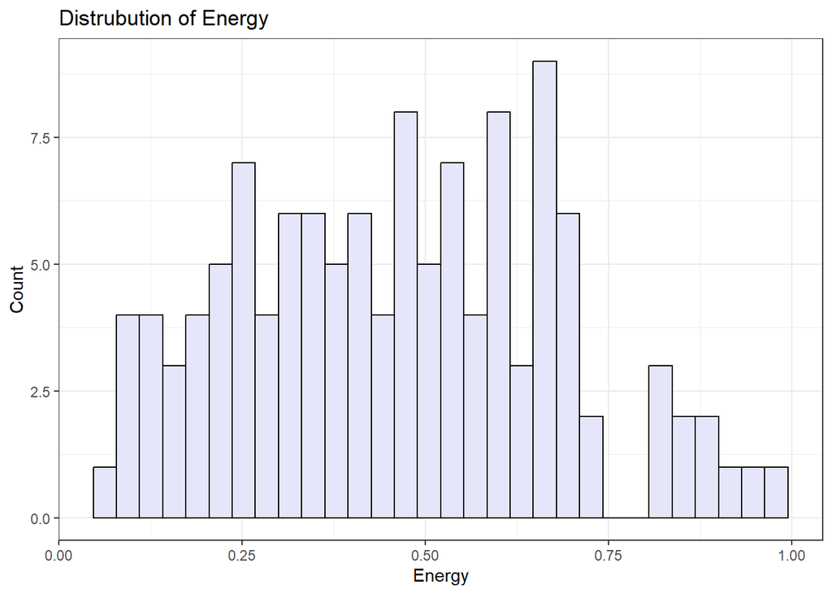

```r
# Histogram of energy

ggplot(Lana_data, aes(energy))+
  geom_histogram(bins=30, color="black", fill="lavender")+
  labs(title="Distrubution of Energy")+
  xlab("Energy")+
  ylab("Count")
```

Based on this plot, we can see that `energy` is pretty well centered but slightly skewed right. There is a wide range of energy levels and not too many high or low values. Most songs are between .2 and .75. Based on the summary data, the median energy is 0.4600 and the mean is 0.4592.

#### Energy by Album

One factor that I think may affect the energy levels of a song is the album. Each album has a different theme and feel, so I expect that this could affect how energetic each song on the album is.

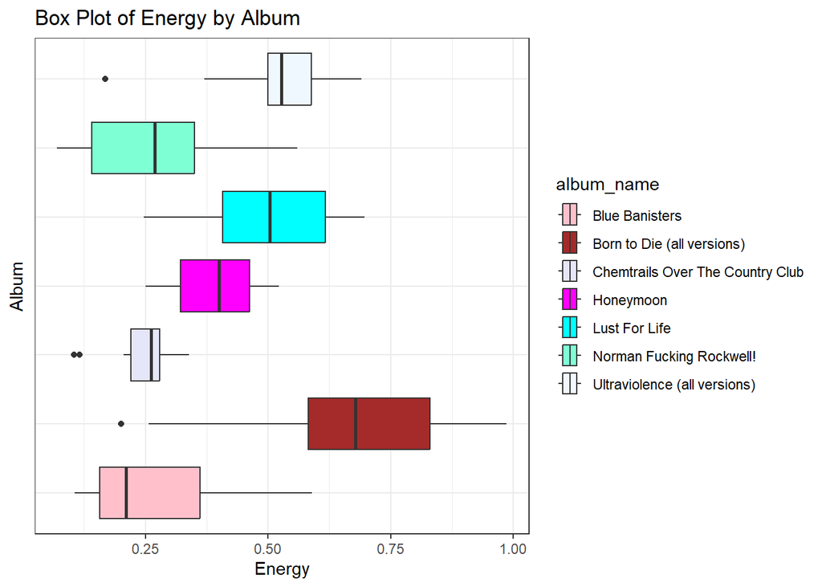

```r
# Box plot of energy  for each album

Lana_data %>%
  ggplot(aes(x = energy, y = album_name, fill=album_name)) +
  geom_boxplot() +
  labs(
    title = "Box Plot of Energy by Album",
    y = "Album",
    x = "Energy") +
  scale_fill_manual(values = c("pink", "brown", "lavender", "magenta", "cyan", "aquamarine", "aliceblue"))+
    theme(axis.text.y = element_blank(),
        axis.ticks.y = element_blank())
```

As expected, the distribution of Energy differs greatly depending on the album. We can see that for the album Blue Banisters, the median energy is about .2 while for Born to Die, the median energy is about .65.

#### Correlation Plot

Now let’s look at the relationships between the variables.

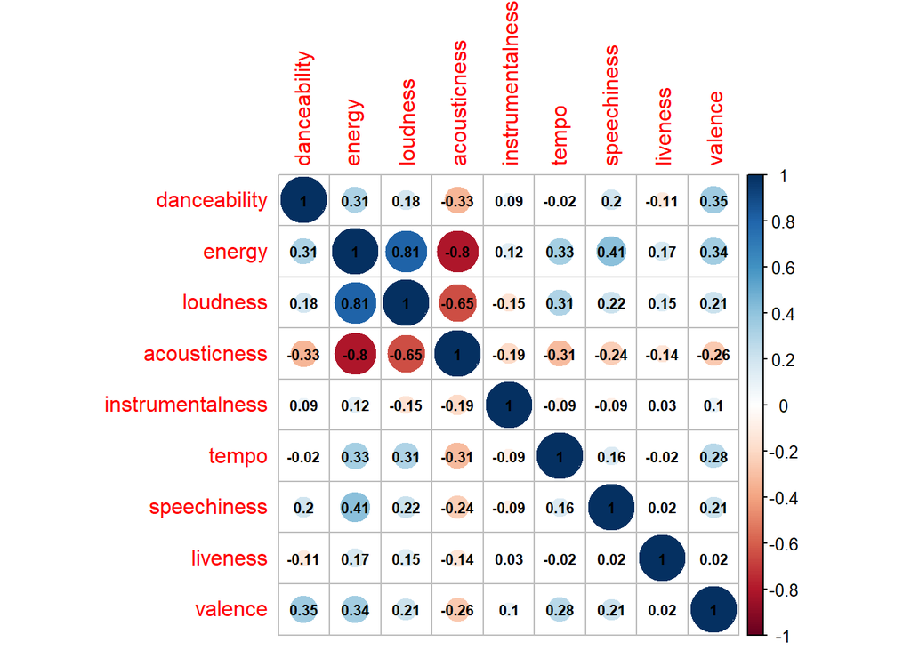

```r
# Only look at the numeric variables

Lana_numeric <- Lana_data %>%
  select_if(is.numeric)

# Correlation matrix

Lana_cor <- cor(Lana_numeric)

# Visualization of correlation matrix

Lana_corrplot <- corrplot(Lana_cor, method = "circle", addCoef.col = 1, number.cex = 0.7)
```

We can see in this plot that `energy` is highly correlated with `loudness` and `acousticness`. There is a correlation of .81 between `energy` and `loudness` which means that as the loudness of a song increases so does energy. This makes sense because I would expect that the louder a song is, the more energetic it is. There is a correlation of -.8 between `acousticness` and `energy` which means that the more acoustic a song is, the less energetic it is. This makes sense because acoustic songs are typically more mellow and calm.

#### Loudness

Since we observed a high correlation between `energy` and `loudness`, let’s take a closer look at this relationship

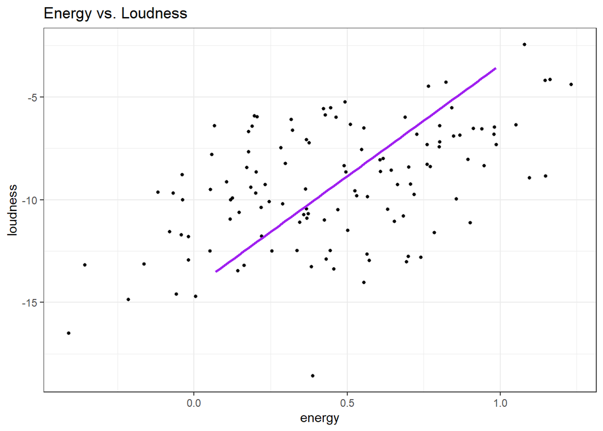

```r
# Scatter plot of energy vs loudness

Lana_data %>%
  ggplot(aes(x=energy, y=loudness)) +
  geom_jitter(width = 0.5, size = 1) +
  geom_smooth(method = "lm", se =F, col="purple") +
  labs(title = "Energy vs. Loudness")
```

We are now able to visualize this positive relationship that we inferred from the correlation plot.

#### Acousticness

Now let’s do the same for acousticness.

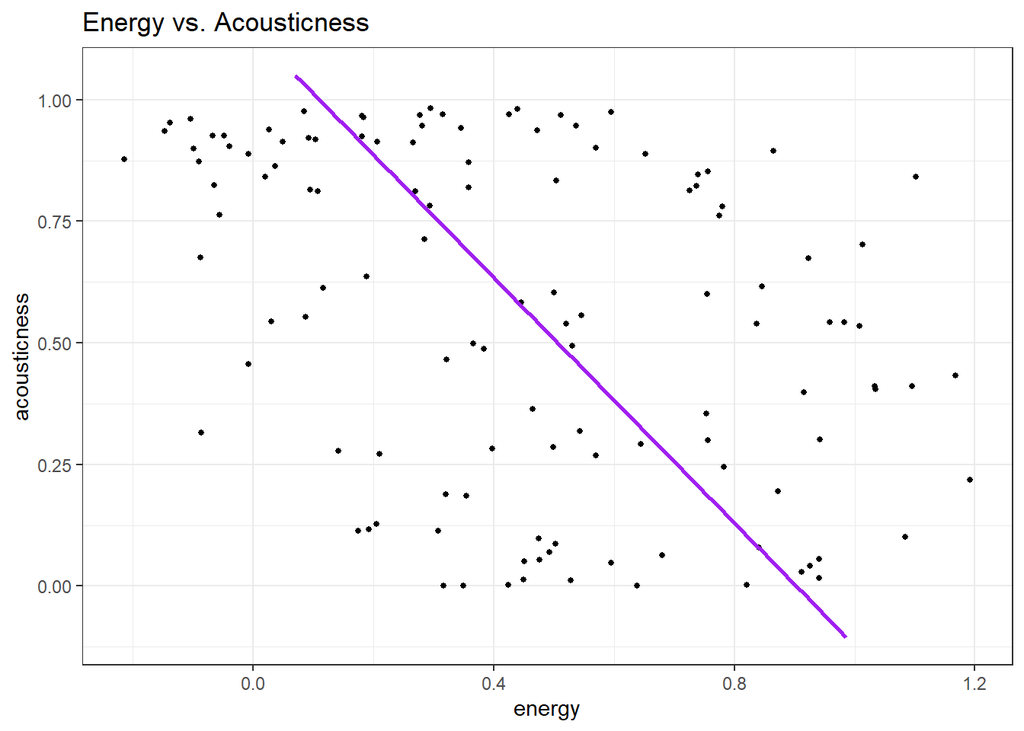

```r
# Scatter plot of energy vs acousticness

Lana_data %>%
  ggplot(aes(x=energy, y=acousticness)) +
  geom_jitter(width = 0.5, size = 1) +
  geom_smooth(method = "lm", se =F, col="purple") +
  labs(title = "Energy vs. Acousticness")
```

Again, there is an apparent negative relationship between the two variables.

## SETTING UP THE MODELS

In order to set up to start fitting models, we must split our data, create a recipe, and create folds for our K-fold cross validation

### Data Splitting

The first step of this process is to split the data into a training and a testing set. The training set is used to train the models while the best model is fit to the testing set to see how well it performs on new data. This is to avoid overfitting. I will be splitting the model into a 70/30 split, stratifying on our outcome `energy`.

```r
# Setting the seed for reproducibility

set.seed(0124)

# Splitting the data (70/30 split, stratify on energy)

Lana_split <- initial_split(Lana_data, prop = 0.7, strata = energy)
Lana_train <- training(Lana_split)
Lana_test <- testing(Lana_split)
```

### Creating Our Recipe

Our next step is to create a recipe for our models. We will use the 8 predictor variables previously mentioned. Finally, we will normalize the variables by centering and scaling.

```r
# Creating recipe

Lana_recipe <- recipe(energy ~loudness + acousticness + instrumentalness + tempo + speechiness + liveness + valence + danceability, data = Lana_train) %>%

  # Normalizing

  step_center(all_predictors()) %>%
  step_scale(all_predictors())
```

### K-Fold Cross Validation

Next, we must create folds for K-fold cross validation. This process is done by splitting the data into the k folds with each fold being a testing set and the other k-1 folds being the training set. The number of folds I have chosen is 10.

```r
# Create 10 folds

Lana_folds <- vfold_cv(Lana_train, v = 10, strata = energy)
```

## BUILDING OUR MODELS

For my models, I will be using a Ridge Regression, Polynomial Regression, K-nearest neighbors, Random Forest, Boosted Trees, and Pruned Decision Tree. I will be using the metric RMSE to compare these models. The RMSE tells us how far the predictions are from the true values, so a lower RMSE would signify a more accurate model.

### Fitting the Models

#### Specify Model Engine

The first step to fitting the models is to specify the model engine.

```r
# SPECIFY MODEL ENGINE

# RIDGE REGRESSION
# Tuning penalty and setting mixture to 0 to specify ridge

ridge_model <- linear_reg(mixture = 0,
                         penalty = tune()) %>%
  set_mode("regression") %>%
  set_engine("glmnet")

# POLYNOMIAL REGRESSION
# Adjusting the recipe because the tuning parameter must be added in the recipe for polynomial regression

poly_recipe <- Lana_recipe %>%
  step_poly(loudness, acousticness, instrumentalness, tempo, speechiness, liveness, valence,
            degree = tune())

poly_model <- linear_reg() %>%
  set_mode("regression") %>%
  set_engine("lm")

# K NEAREST NEIGHBORS
# Tuning the number of neighbors

knn_model <- nearest_neighbor(neighbors = tune()) %>%
  set_mode("regression") %>%
  set_engine("kknn")

# RANDOM FOREST
# Tuning mtry (number of predictors), trees, and min_n (number of minimum values in each node), and setting importance="impurity"

rf_model <- rand_forest(mtry = tune(),
                       trees = tune(),
                       min_n = tune()) %>%
  set_engine("ranger", importance = "impurity") %>%
  set_mode("regression")

# BOOSTED TREES
# Tuning mtry, trees, learn_rate (the learning rate)

boosted_model <- boost_tree(mtry = tune(),
                           trees = tune(),
                           learn_rate = tune()) %>%
  set_engine("xgboost") %>%
  set_mode("regression")

# PRUNED DECISION TREE
# Tuning cost_complexity

prune_model <- decision_tree(cost_complexity = tune()) %>%
  set_engine("rpart") %>%
  set_mode("regression")
```

#### Set up Workflow

Next, we set up the workflow by adding the model and the recipe.

```r
# SET UP WORKFLOW

# RIDGE REGRESSION

ridge_workflow <- workflow() %>%
  add_recipe(Lana_recipe) %>%
  add_model(ridge_model)

# POLYNOMIAL REGRESSION

poly_workflow <- workflow() %>%
  add_model(poly_model) %>%
  add_recipe(poly_recipe)

# K NEAREST NEIGHBORS

knn_workflow <- workflow() %>%
  add_model(knn_model) %>%
  add_recipe(Lana_recipe)

# RANDOM FOREST

rf_workflow <- workflow() %>%
  add_recipe(Lana_recipe) %>%
  add_model(rf_model)

# BOOSTED TREES

boosted_workflow <- workflow() %>%
  add_recipe(Lana_recipe) %>%
  add_model(boosted_model)

# PRUNED DECISION TREE

prune_workflow <- workflow() %>%
  add_recipe(Lana_recipe) %>%
  add_model(prune_model)
```

#### Create Grid

We must create a tuning grid to specify the ranges of the parameters we want to tune and the number of levels.

```r
# CREATE GRID

# RIDGE REGRESSION

ridge_grid <- grid_regular(penalty(range = c(-5, 5)),
                           levels = 30)

# POLYNOMIAL REGRESSION

poly_grid <- grid_regular(degree(range = c(1,7)),
                          levels = 7)

# K NEAREST NEIGHBORS

knn_grid <- grid_regular(neighbors(range = c(1,10)),
                         levels = 10)

# RANDOM FOREST

rf_grid <- grid_regular(mtry(range = c(1, 6)),
                        trees(range = c(100,800)),
                        min_n(range = c(5,20)),
                        levels = 5)

# BOOSTED TREES

boosted_grid <- grid_regular(mtry(range = c(1, 5)),
                             trees(range = c(5, 400)),
                             learn_rate(range = c(-0.1, 0)),
                             levels = 5)

#PRUNED DECISION TREE

prune_grid <- grid_regular(cost_complexity(range=c(-3, -1)),
                             levels = 10)
```

#### Tune the Models

Now, we tune the model, specify the workflow, the folds, and the tuning grid.

```r
#TUNE MODELS

#RIDGE REGRESSION

ridge_tune <- tune_grid(
  ridge_workflow,
  resamples = Lana_folds,
  grid = ridge_grid
)

# POLYNOMIAL REGRESSION

poly_tune <- tune_grid(
  poly_workflow,
  resamples = Lana_folds,
  grid = poly_grid
)

# K NEAREST NEIGHBORS

knn_tune <- tune_grid(
    knn_workflow,
    resamples = Lana_folds,
    grid = knn_grid
)

# RANDOM FOREST

rf_tune <- tune_grid(
  rf_workflow,
  resamples = Lana_folds,
  grid = rf_grid
)

# BOOSTED TREES

boosted_tune <- tune_grid(
  boosted_workflow,
  resamples = Lana_folds,
  grid = boosted_grid
)

# PRUNED DECISION TREE

prune_tune <- tune_grid(
  prune_workflow,
  resamples = Lana_folds,
  grid = prune_grid
)
```

#### Save and Load Files

Save and load in the tuned models.

```r
# SAVE AND LOAD IN FILES

# RIDGE REGRESSION

save(ridge_tune, file = "Akim-FinalProject/tuned_models/ridge.rda")
load("Akim-FinalProject/tuned_models/ridge.rda")

# POLYNOMIAL REGRESSION

save(poly_tune, file = "Akim-FinalProject/tuned_models/poly.rda")
load("Akim-FinalProject/tuned_models/poly.rda")

# K NEAREST NEIGHBORS

save(knn_tune, file = "Akim-FinalProject/tuned_models/knn.rda")
load("Akim-FinalProject/tuned_models/knn.rda")

# RANDOM FOREST

save(rf_tune, file = "Akim-FinalProject/tuned_models/rf.rda")
load("Akim-FinalProject/tuned_models/rf.rda")

# BOOSTED TREES

save(boosted_tune, file = "Akim-FinalProject/tuned_models/boosted.rda")
load("Akim-FinalProject/tuned_models/boosted.rda")

# PRUNED DECISION TREE

save(boosted_tune, file = "Akim-FinalProject/tuned_models/prune.rda")
load("Akim-FinalProject/tuned_models/prune.rda")
```

#### Select the Best Model

The best values for each model will now be selected, using the metric RMSE.

```r
# SELECT BEST MODEL

# RIDGE REGRESSION

best_ridge <- select_best(ridge_tune, metric="rmse")

# POLYNOMIAL REGRESSION

best_poly <- select_best(poly_tune)

# K NEAREST NEIGHBORS

best_knn<-select_by_one_std_err(knn_tune, desc(neighbors), metric = "rmse")

# RANDOM FOREST

best_rf <- select_best(rf_tune, metric="rmse")

# BOOSTED TREES

best_boosted <- select_best(boosted_tune, metric = "rmse")

# PRUNED DECISON TREE

best_prune <- select_best(prune_tune, metric='rmse')
```

#### Fit Best Model

Now the best models must be fit using the whole training data set.

```r
# FIT BEST MODEL TO TRAINING

# RIDGE REGRESSION

ridge_final <- finalize_workflow(ridge_workflow, best_ridge)
ridge_final_fit <-fit(ridge_final, data=Lana_train)

# POLYNOMIAL REGRESSION

poly_final <- finalize_workflow(poly_workflow, best_poly)
poly_final_fit <- fit(poly_final, data = Lana_train)

# K NEAREST NEIGHBORS

knn_final <- finalize_workflow(knn_workflow, best_knn)
knn_final_fit<-fit(knn_final, Lana_train)

# RANDOM FOREST

rf_final <- finalize_workflow(rf_workflow, best_rf)
rf_final_fit <- fit(rf_final, Lana_train)

# BOOSTED TREES

boosted_final <- finalize_workflow(boosted_workflow, best_boosted)
boosted_final_fit<-fit(boosted_final, Lana_train)

# PRUNED DECISION TREE

prune_final <- finalize_workflow(prune_workflow, best_prune)
prune_final_fit<-fit(prune_final, Lana_train)
```

#### Calculate Performance

These final models can now be applied to the testing data to assess their abilities.

```r
# CALCULATE PERFORMANCE

# RIDGE REGRESSION

ridge_rmse <- augment(ridge_final_fit, new_data=Lana_test) %>%
  rmse(truth=energy, estimate=.pred)%>%
  select(.estimate)

# POLYNOMIAL REGRESSION

poly_metrics <- metric_set(rmse, rsq)
poly_rmse <- augment(poly_final_fit, new_data = Lana_test) %>%
  poly_metrics(energy, .pred)%>%
  slice(1)%>%
  select(.estimate)

# K NEAREST NEIGHBORS

knn_rmse <- augment(knn_final_fit, new_data = Lana_test) %>%
  rmse(truth = energy, estimate = .pred)%>%
  select(.estimate)

# RANDOM FOREST

rf_rmse <- augment(rf_final_fit, new_data = Lana_test) %>%
  rmse(truth = energy, estimate = .pred)%>%
  select(.estimate)

# BOOSTED TREES

boosted_rmse <- augment(boosted_final_fit, new_data = Lana_test) %>%
  rmse(truth = energy, estimate = .pred)%>%
  select(.estimate)

#PRUNED DECISION TREE

prune_rmse <- augment(prune_final_fit, new_data = Lana_test) %>%
  rmse(truth = energy, estimate = .pred) %>%
  select(.estimate)
```

## RESULTS

Now we will view and compare the results of our models to see which model has performed the best.

```r
# Create data frame of all RMSE

Model = c("Ridge Reg", "Poly Reg", "KNN", "Rand Forest", "Boosted Trees", "Pruned Tree")

RMSE = c(ridge_rmse$.estimate, poly_rmse$.estimate, knn_rmse$.estimate, rf_rmse$.estimate, boosted_rmse$.estimate, prune_rmse$.estimate)

Lana_results <- tibble(Model = Model,
                      RMSE = RMSE)

Lana_results <- Lana_results %>%
  dplyr::arrange(RMSE)

Lana_results
```

```
## # A tibble: 6 × 2
##   Model           RMSE
##   <chr>          <dbl>
## 1 Ridge Reg     0.0893
## 2 Rand Forest   0.0911
## 3 Poly Reg      0.0970
## 4 KNN           0.0987
## 5 Boosted Trees 0.104
## 6 Pruned Tree   0.141
```

It seems like the Ridge Regression has performed the best! All of our models performed relatively well as the RMSE range from only .141 to .089. This means that the worst model’s (pruned decision tree) predictions differ from the actual values by .141 while the best model’s predictions differ from the actual values by .089.

Now let’s visualize this result.

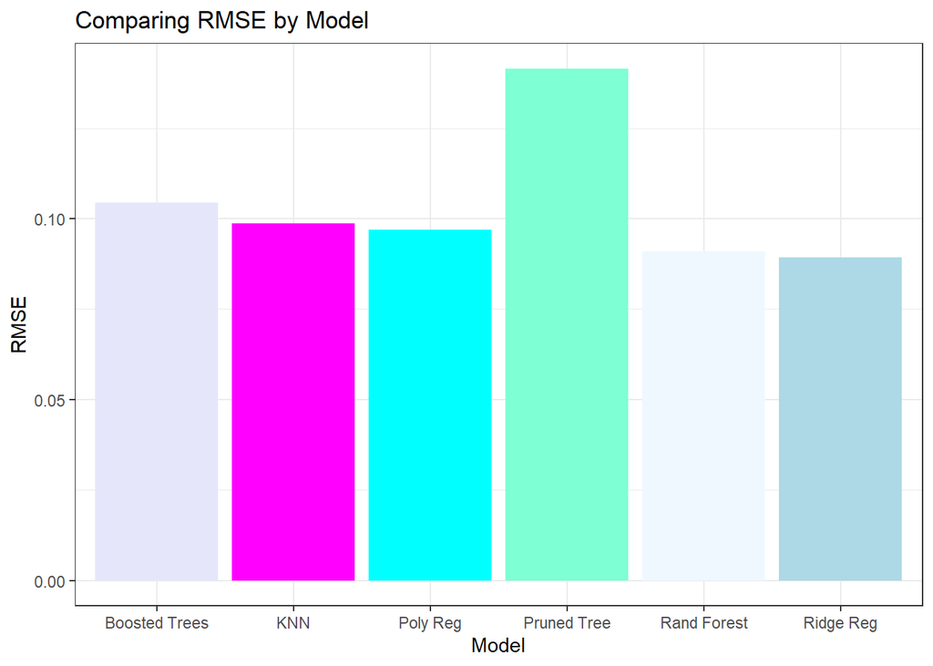

```r
# Creating a bar plot of the RMSE values

ggplot(Lana_results, aes(x=Model, y=RMSE)) +
  geom_bar(stat = "identity", aes(fill = Model)) +
  scale_fill_manual(values = c("lavender", "magenta", "cyan", "aquamarine", "aliceblue", "lightblue")) +
  theme(legend.position = "none") +
  labs(title = "Comparing RMSE by Model")
```

### Autoplots

In order to visualize the effects of the tuned parameters, let’s look at the autoplots. Note that a lower RMSE signifies a better model.

#### Ridge Regression

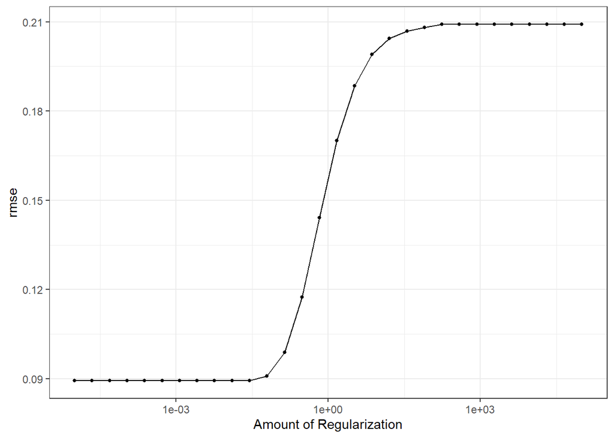

```r
autoplot(ridge_tune, metric = 'rmse')
```

In this plot, we can see that the model performs better at lower penalty values.

#### Random Forest

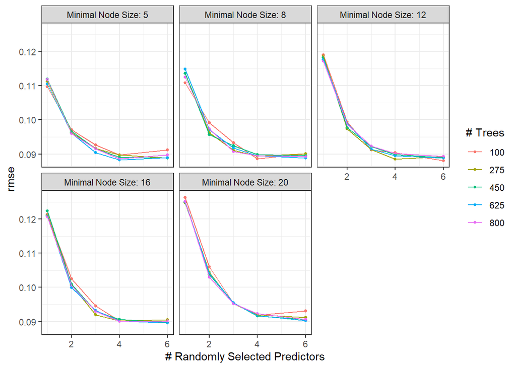

```r
autoplot(rf_tune, metric = 'rmse')
```

In this plot we can see that the model performs better at higher randomly selected predictor values, less trees, and lower minimal node size.

#### Polynomial Regression

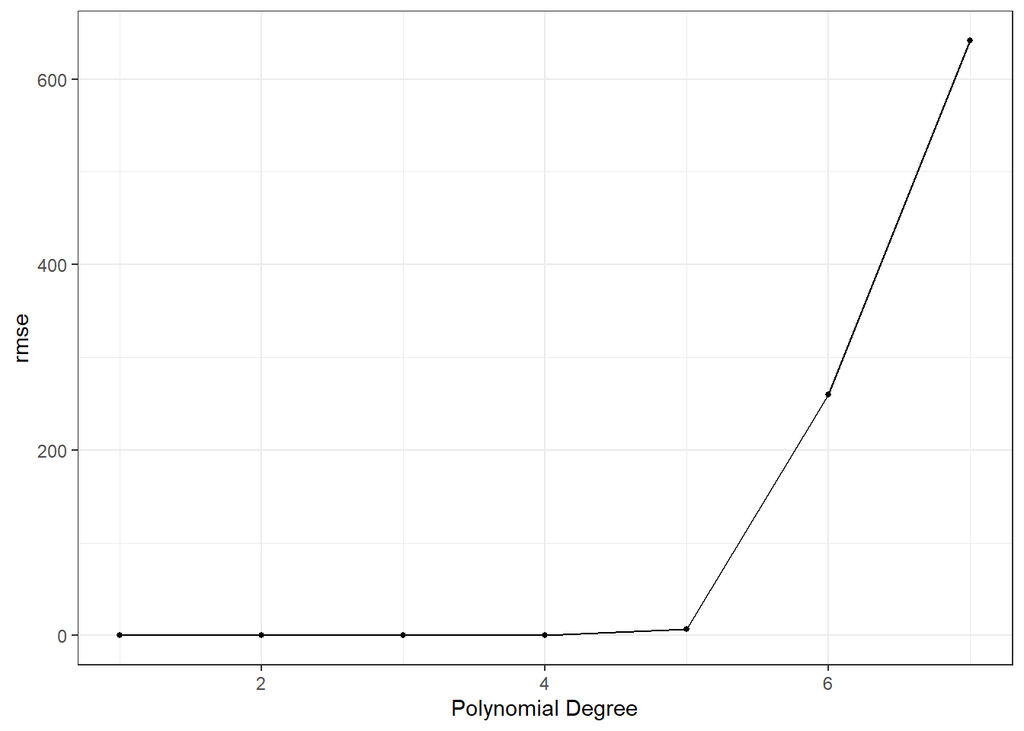

```r
autoplot(poly_tune, metric = 'rmse')
```

In this plot, we can see that the model performs better when the degree is lower.

#### Boosted Trees

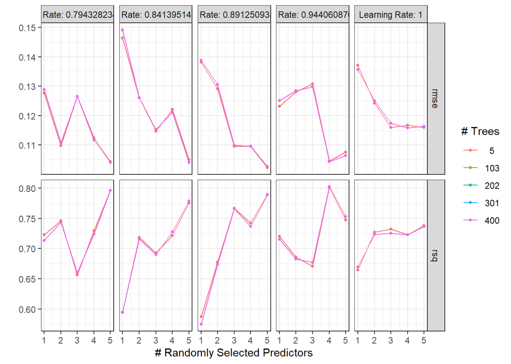

```r
autoplot(boosted_tune)
```

In this plot, we can see that the model performs better at a lowe number of trees, higher number of randomly selected predictors, and it seems to vary across the different learning rates.

#### Pruned Decision Tree

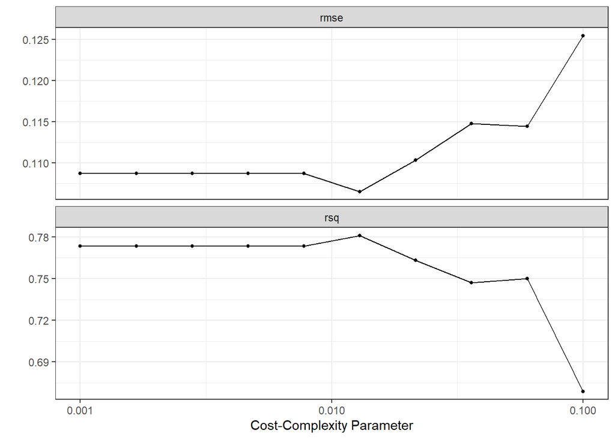

```r
autoplot(prune_tune)
```

In this plot, we can see that the model performs better as cost complexity decreases. Another visualization for the pruned decision tree is to extract the model fit results and view them with `rpart.plot()`.

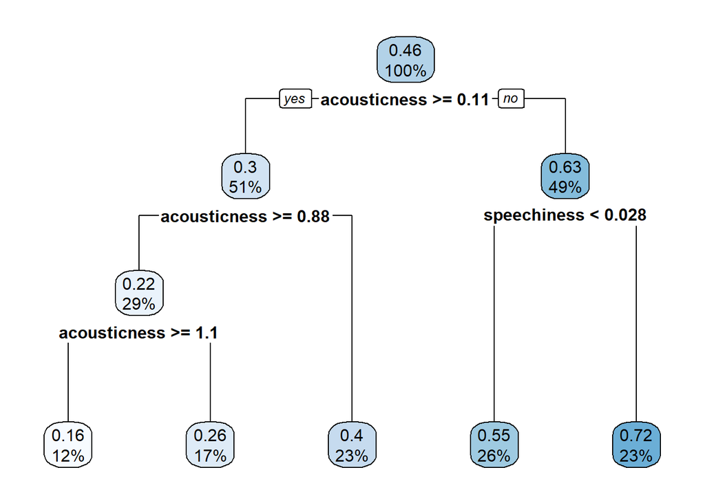

```r
# Extract model fit results

prune_final_fit %>%
  extract_fit_engine() %>%
  rpart.plot(roundint = FALSE)
```

## BEST MODELS

### Ridge Regression

Our best model was the Ridge Regression model, as it had the lowest RMSE.

#### Which Fold?

Let’s now see which parameters were chosen as the best Ridge Regression model.

```r
# Select the best fold

ridge_tune %>%
  collect_metrics() %>%
  filter(.metric == "rmse") %>%
  arrange(mean) %>%
  slice(1)
```

```
## # A tibble: 1 × 7
##   penalty .metric .estimator   mean     n std_err .config
##     <dbl> <chr>   <chr>       <dbl> <int>   <dbl> <chr>
## 1  0.0281 rmse    standard   0.0893    10 0.00902 Preprocessor1_Model11
```

Ridge regression 11 with a penalty of .028 and RMSE of .0893 performed the best.

#### Fit to Training Data

Now we will fit the best model to the training data.

```r
# Fitting to the training data

best_ridge <- select_best(ridge_tune)

final_ridge_model <- finalize_workflow(ridge_workflow, best_ridge)

final_ridge_model<- fit(final_ridge_model, Lana_train)
```

### Testing the Model

Next, let’s test the model to see how it performs on the testing set.

```r
# Collecting the rmse of the model on the testing data

final_ridge_model_test <- augment(final_ridge_model, Lana_test)

rmse(final_ridge_model_test, truth = energy, .pred)
```

```
## # A tibble: 1 × 3
##   .metric .estimator .estimate
##   <chr>   <chr>          <dbl>
## 1 rmse    standard      0.0893
```

Our model performed the same on the testing set with an RMSE of .0893 as well.

### Random Forest

The Random Forest performed the second best, as it had the second lowest RMSE value.

#### Which Fold?

Let’s now see which parameters were chosen as the best Random Forest model.

```r
# Select the best fold

rf_tune %>%
  collect_metrics() %>%
  filter(.metric == "rmse") %>%
  arrange(mean) %>%
  slice(1)
```

```
## # A tibble: 1 × 9
##    mtry trees min_n .metric .estimator   mean     n std_err .config
##   <int> <int> <int> <chr>   <chr>       <dbl> <int>   <dbl> <chr>
## 1     6   100    12 rmse    standard   0.0880    10 0.00897 Preprocessor1_Model…
```

Random forest 55 with 6 predictors, 100 trees, and a node size of 12 perfomed the best with an RMSE of .0880.

#### Fit to Training Data

Now we will fit the best model to the training data.

```r
# Fitting to the training data

best_rf <- select_best(rf_tune)

final_rf_model <- finalize_workflow(rf_workflow, best_rf)

final_rf_model<- fit(final_rf_model, Lana_train)
```

#### Testing the Model

Next, let’s test the model to see how it performs on the testing set.

```r
# Collecting the rmse of the model on the testing data

final_rf_model_test <- augment(final_rf_model, Lana_test)

rmse(final_rf_model_test, truth = energy, .pred)
```

```
## # A tibble: 1 × 3
##   .metric .estimator .estimate
##   <chr>   <chr>          <dbl>
## 1 rmse    standard      0.0878
```

### Variable Importance

Let’s check which variables were the most influential in predicting the outcome.

#### Ridge Regression

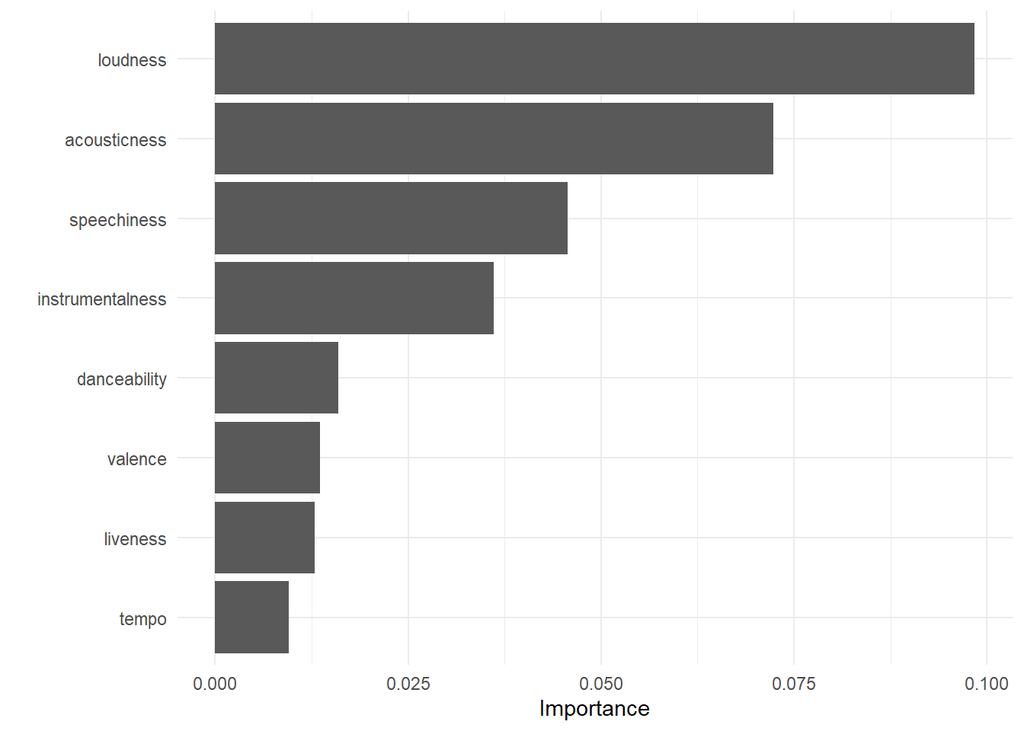

```r
# Plot the variable importance
final_ridge_model %>% extract_fit_parsnip() %>%
  vip() +
  theme_minimal()
```

For the Ridge Regression, the most important variable was `loudness` with `acousticness` as the second most important. The rest of the variables had lower importance in predicting the outcome. In our visual EDA, we saw that energy had a high correlation with both of these variables, so this outcome makes sense.

#### Random Forest

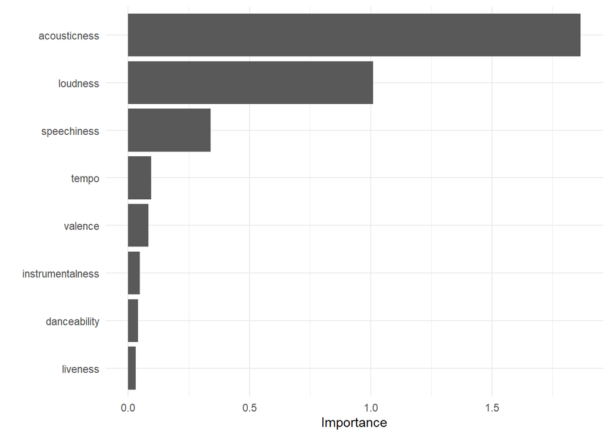

```r
# Plot the variable importance

final_rf_model %>% extract_fit_parsnip() %>%
  vip() +
  theme_minimal()
```

For the Random Forest, the most important variable was `acousticness` with `loudness` as the second most important. The rest of the variables had very low importance in predicting the outcome. Again, since we saw that energy had a high correlation with both of these variables, this outcome makes sense.

### Predicted vs. Actual

Let’s now plot the predicted values vs the actual values. Note that if every observation was predicted accurately the dots would form a straight line.

#### Ridge Regression

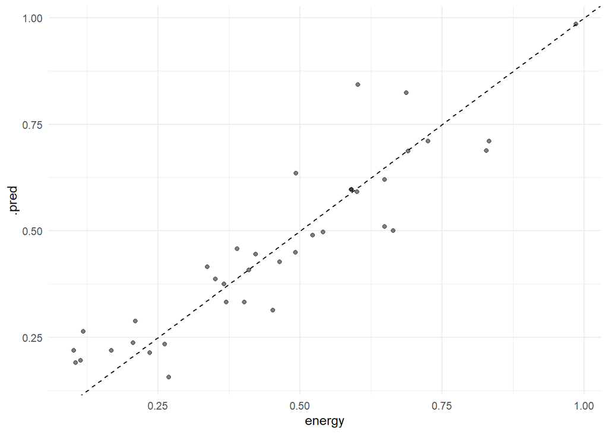

```r
# Create plot of predicted vs. actual values

final_ridge_model_test %>%
  ggplot(aes(x = energy, y = .pred)) +
  geom_point(alpha = 0.5) +
  geom_abline(lty = 2) +
  theme_minimal()
```

There is a general straight line trend in this plot signifying that our Ridge Regression was pretty accurate in predicting the observations. This makes sense because we had a relatively low RMSE of .0893 meaning the predicted values are not far off from the actual values.

#### Random Forest

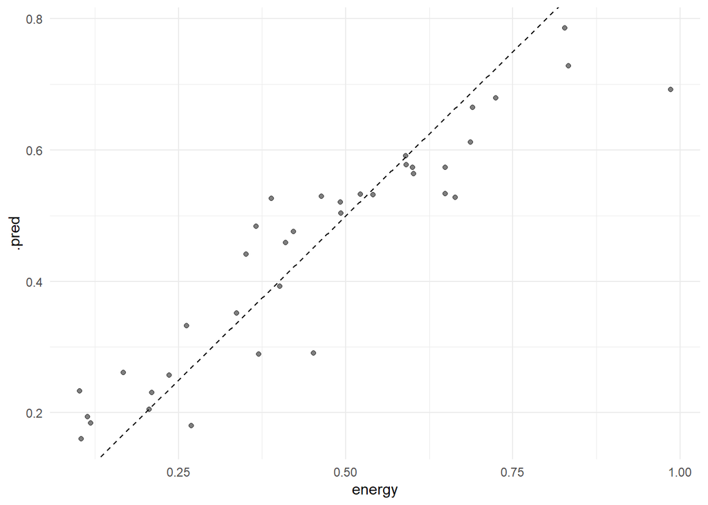

```r
# Create plot of predicted vs. actual values

final_rf_model_test %>%
  ggplot(aes(x = energy, y = .pred)) +
  geom_point(alpha = 0.5) +
  geom_abline(lty = 2) +
  theme_minimal()
```

## CONCLUSION

Now that we have fit different kinds of model and analyzed them, we know that the best model to predict the energy level of a Lana Del Rey song is the ridge regression. The ridge regression is able to handle multicollinearity, improve model stability, and achieves good generalization performance, so this outcome makes sense. Our specific ridge regression was quite accurate with predicting energy based on our RMSE calculation.

The worst model was the pruned decision tree. The pruned decision tree removes branches and nodes from the decision tree to simplify its structure. As a result, the pruned tree may lack complexity which could explain its poor performance.

Something that I discussed before was the different distributions of energy by album. One thing I could do to improve my models would be to redo them for each album. I think this could lead to higher accuracy, as the distributions of energy differ quite significantly by album.

Another question I would like to explore is whether this would work as a classification problem. I left out the variable `key_mode` which represents whether the track is major or minor. I think that this variable could help with predicting energy levels, as major keys are typically characterized by higher energy levels. I believe that my model might perform better if I include this variable.

Overall, my Lana Del Rey Energy Model performed better than expected. I initially didn’t think that the energy of Lana Del Rey’s song would be easy to predict due to the versatility of her music.